# Phodopus molecular evolution

## Step 4: Estimation of synonymous (dS) and nonysynonymous (dN) substitution rates

We used codeml within the PAML program to estimate rates of synonymous (dS) and non-synonymous (dN) substitutions using a free-ratio model (model=1, NSsites=0) to get an estimate of rate for each branch in our phylogeny. Relationships among genes may differ amongst themselves and relative to the species relationships due to biological factors such as incomplete lineage sorting and introgression. In cases where a gene tree and the species tree disagree, inferring substitutions using the species tree (the wrong tree in this case) can lead to spurious inferences of substitutions and affect rate estimates. To mitigate this, we used the corresponding gene tree for each alignment when estimating rates. When compiling rate estimates, we only counted rates for a branch in the species tree if it existed in the gene tree (Table 2).

```r
t2_data = data.frame("Branch"=c(), "Gene trees"=c(), "Genes after dS filter"=c())
for(clade_label in rodent_data$clade.label){
  if(rodent_data$node.type[rodent_data$clade.label==clade_label]!="internal"){
    next
  }

  t2_data = rbind(t2_data, data.frame("Branch"=clade_label, "Gene trees"=clade_data[[clade_label]], "Genes after dS filter"=length(clade_data_f[[clade_label]][,1])))
}

rownames(t2_data) = c()

t2_data %>% kable(col.names=c("Branch","Monophyletic gene trees", "Genes after dS filter"), caption="Number of gene trees containing branch before and after dS filtering", align="l") %>% kable_styling(bootstrap_options=c("striped", "condensed", "responsive"), full_width=F)# %>%
```

Number of gene trees containing branch before and after dS filtering

| Branch | Monophyletic gene trees | Genes after dS filter |
| --- | --- | --- |
| 10 | 5523 | 1172 |
| 11 | 5238 | 5146 |
| pho | 5394 | 5325 |
| 13 | 5378 | 5306 |
| 14 | 5367 | 5313 |
| mus | 5501 | 5496 |

```r
  #column_spec(1, width="7em") %>%
  #column_spec(2, width="13em")
```

### Filtering based on dS

As another check on alignment quality, we assessed distributions of dS along each branch and only counted genes for each branch where dS fell below 0.3. (QUESTION: should this dS filter step have a different threshold for each branch?) We also omitted genes for a branch where dN/dS was greater than 2.

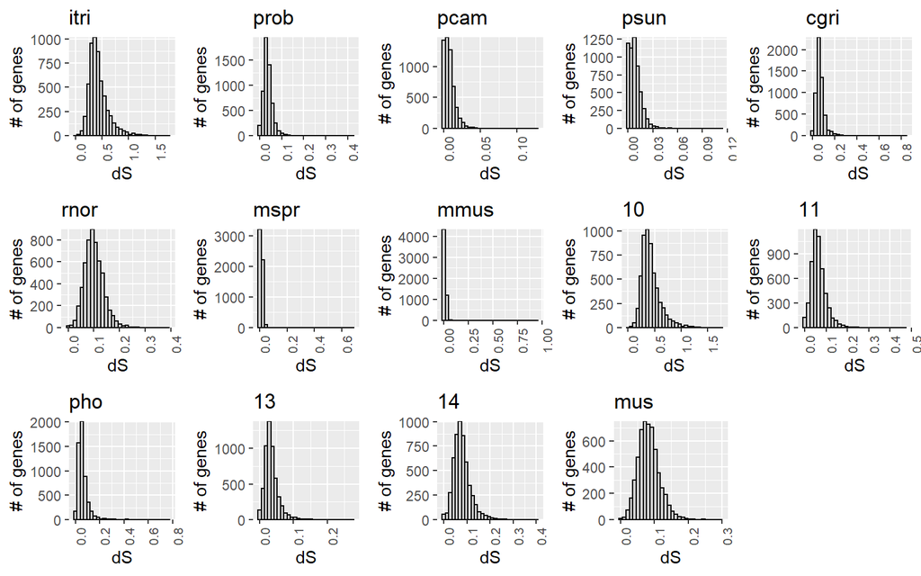

```r
ds_plots = plot_grid(plotlist=ds_dists, nrow=3)
print(ds_plots)
```

### Post filter dS distributions per branch

(QUESTION: Do we need to correct for divergence time somehow?)

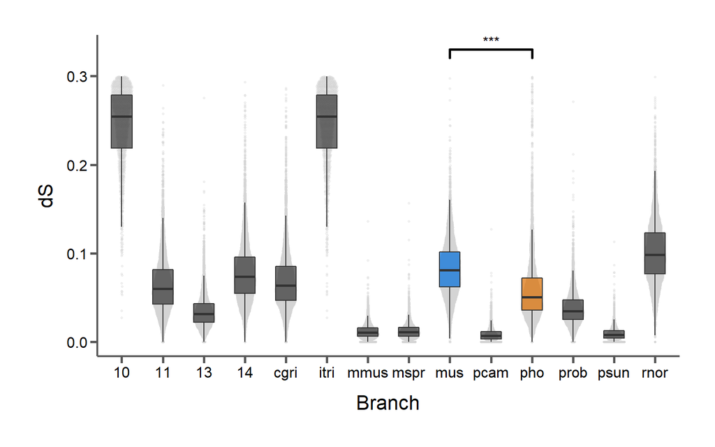

```r
m1_data_f = do.call("rbind", clade_data_f)

clade_cols = as.character(rodent_data$clade.col)
clade_labs = as.character(rodent_data$clade.label)

x_comps = list(c("mus", "pho"))

clade_ds_p = ggplot(m1_data_f, aes(clade.label, clade.ds, fill=clade.label)) +
  geom_quasirandom(size=0.5, alpha=0.3, width=0.25, color="#d3d3d3") +
  geom_boxplot(outlier.shape=NA, alpha=0.7, width=0.5) +
  geom_signif(comparisons=x_comps, map_signif_level=TRUE, textsize=4, size=1, step_increase=0.12, margin_top=0.1) +
  xlab("Branch") +
  ylab("dS") +
  scale_fill_manual(limits=clade_labs, values=clade_cols) +
  bartheme() +
  theme(legend.position="none")

print(clade_ds_p)
```

### Post filter dN distributions per branch

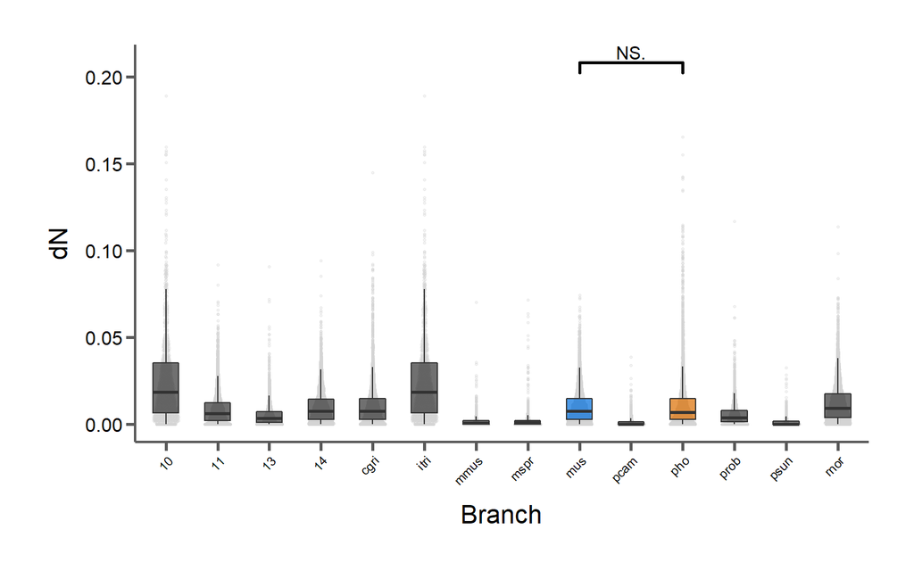

```r
clade_cols = as.character(rodent_data$clade.col)
clade_labs = as.character(rodent_data$clade.label)

x_comps = list(c("mus", "pho"))

clade_dn_p = ggplot(m1_data_f, aes(clade.label, clade.dn, fill=clade.label)) +
  geom_quasirandom(size=0.5, alpha=0.3, width=0.25, color="#d3d3d3") +
  geom_boxplot(outlier.shape=NA, alpha=0.7, width=0.5) +
  geom_signif(comparisons=x_comps, map_signif_level=TRUE, textsize=4, size=1, step_increase=0.12, margin_top=0.1) +
  xlab("Branch") +
  ylab("dN") +
  scale_fill_manual(limits=clade_labs, values=clade_cols) +
  bartheme() +
  theme(legend.position="none",
        axis.text.x = element_text(angle=45, hjust=1, size=8)
        )

print(clade_dn_p)
```

### Post filter dN/dS distributions per branch

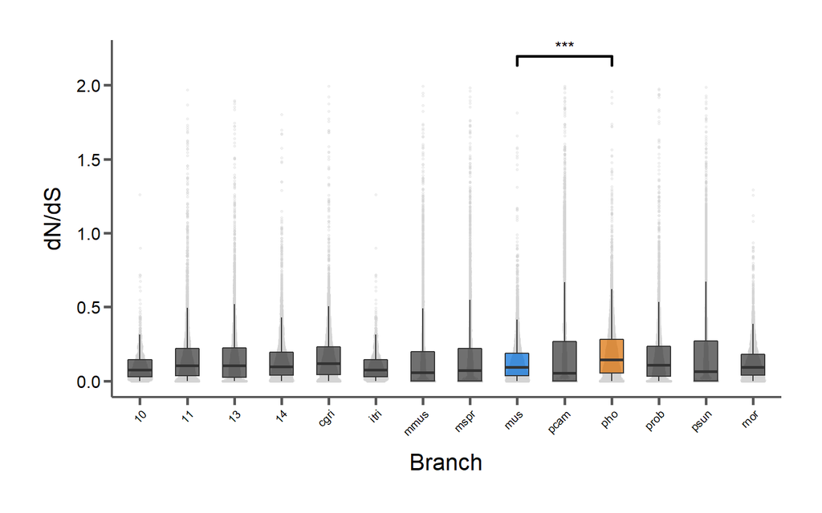

```r
clade_cols = as.character(rodent_data$clade.col)
clade_labs = as.character(rodent_data$clade.label)

x_comps = list(c("mus", "pho"))

clade_dnds_p = ggplot(m1_data_f, aes(clade.label, clade.dn.ds, fill=clade.label)) +
  geom_quasirandom(size=0.5, alpha=0.3, width=0.25, color="#d3d3d3") +
  geom_boxplot(outlier.shape=NA, alpha=0.7, width=0.5) +
  geom_signif(comparisons=x_comps, map_signif_level=TRUE, textsize=4, size=1, step_increase=0.12, margin_top=0.1) +
  xlab("Branch") +
  ylab("dN/dS") +
  scale_fill_manual(limits=clade_labs, values=clade_cols) +
  bartheme() +
  theme(legend.position="none",
        axis.text.x = element_text(angle=45, hjust=1, size=8)
        )

print(clade_dnds_p)
```

# Results

## 1. X vs. autosome dS distributions in Mus and Phodopus

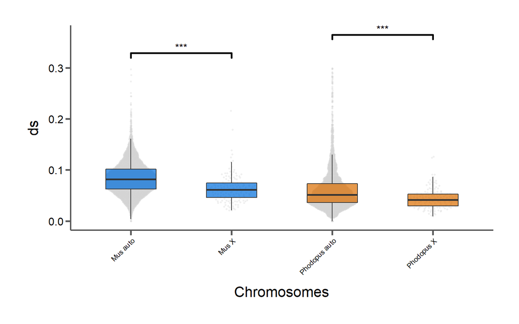

```r
phodopus_x = subset(clade_data_f[["pho"]], pho.chr=="chrXr" | pho.chr=="chrXn")
phodopus_x$chrome = "Phodopus X"
phodopus_a = subset(clade_data_f[["pho"]], pho.chr!="chrXr" & pho.chr!="chrXn")
phodopus_a$chrome = "Phodopus auto"

mus_x = subset(clade_data_f[["mus"]], mm10.chr=="chrX")
mus_x$chrome = "Mus X"
mus_a = subset(clade_data_f[["mus"]], mm10.chr!="chrX")
mus_a$chrome = "Mus auto"

chrome_data = rbind(mus_a, mus_x, phodopus_a, phodopus_x)

#clade_cols = as.character(rodent_data$clade.col)
#clade_labs = as.character(rodent_data$clade.label)

chrome_cols = c("#006ddb", "#006ddb", "#db6d00", "#db6d00")
chrome_labs = c("Mus auto", "Mus X", "Phodopus auto", "Phodopus X")

x_comps = list(c("Mus auto", "Mus X"), c("Phodopus auto", "Phodopus X"))

chrome_ds_p = ggplot(chrome_data, aes(chrome, clade.ds, fill=chrome)) +
  geom_quasirandom(size=0.5, alpha=0.3, width=0.25, color="#d3d3d3") +
  geom_boxplot(outlier.shape=NA, alpha=0.7, width=0.5) +
  geom_signif(comparisons=x_comps, map_signif_level=TRUE, textsize=4, size=1, step_increase=0.12, margin_top=0.1) +
  xlab("Chromosomes") +
  ylab("ds") +
  scale_fill_manual(limits=chrome_labs, values=chrome_cols) +
  bartheme() +
  theme(legend.position="none",
        axis.text.x = element_text(angle=45, hjust=1, size=8)
        )

print(chrome_ds_p)
```

## 2. X vs. autosome dN distributions in Mus and Phodopus

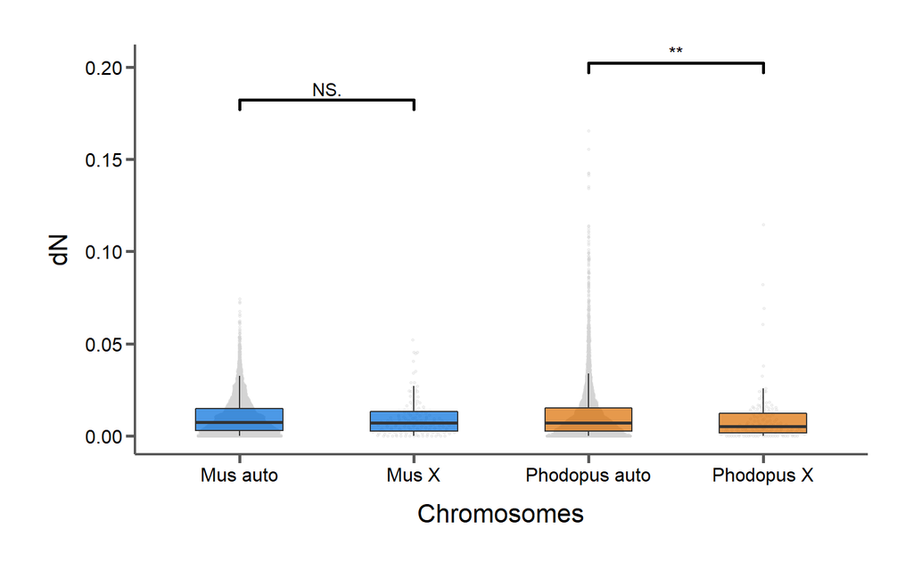

```r
chrome_cols = c("#006ddb", "#006ddb", "#db6d00", "#db6d00")
chrome_labs = c("Mus auto", "Mus X", "Phodopus auto", "Phodopus X")

x_comps = list(c("Mus auto", "Mus X"), c("Phodopus auto", "Phodopus X"))

chrome_dn_p = ggplot(chrome_data, aes(chrome, clade.dn, fill=chrome)) +
  geom_quasirandom(size=0.5, alpha=0.3, width=0.25, color="#d3d3d3") +
  geom_boxplot(outlier.shape=NA, alpha=0.7, width=0.5) +
  geom_signif(comparisons=x_comps, map_signif_level=TRUE, textsize=4, size=1, step_increase=0.12, margin_top=0.1) +
  xlab("Chromosomes") +
  ylab("dN") +
  scale_fill_manual(limits=chrome_labs, values=chrome_cols) +
  bartheme() +
  theme(legend.position="none")

print(chrome_dn_p)
```

## 3. X vs. autosome dN/dS distributions in Mus and Phodopus

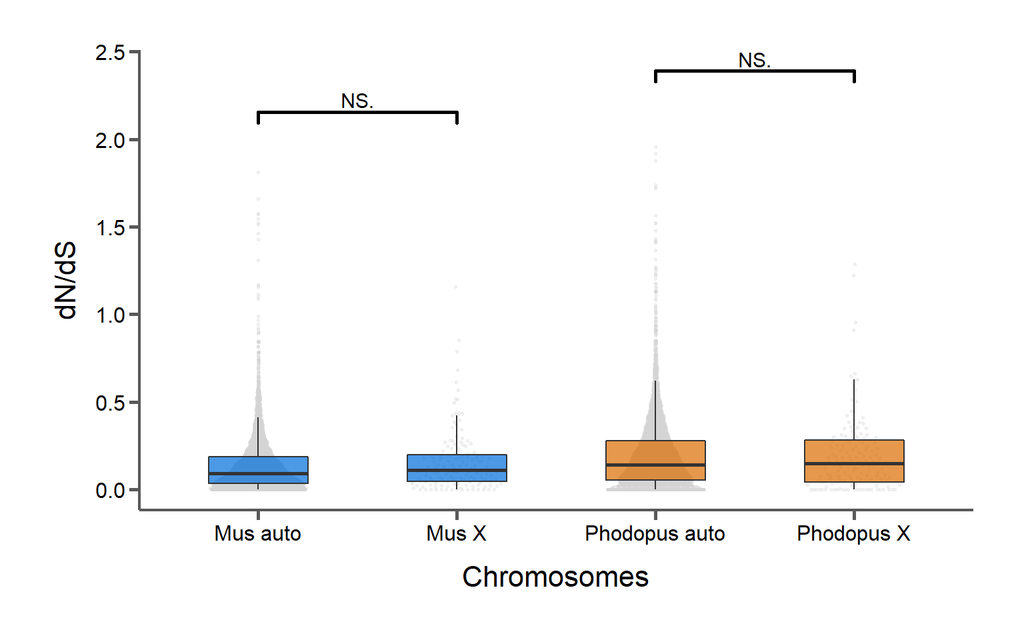

```r
chrome_cols = c("#006ddb", "#006ddb", "#db6d00", "#db6d00")
chrome_labs = c("Mus auto", "Mus X", "Phodopus auto", "Phodopus X")

x_comps = list(c("Mus auto", "Mus X"), c("Phodopus auto", "Phodopus X"))

chrome_dnds_p = ggplot(chrome_data, aes(chrome, clade.dn.ds, fill=chrome)) +
  geom_quasirandom(size=0.5, alpha=0.3, width=0.25, color="#d3d3d3") +
  geom_boxplot(outlier.shape=NA, alpha=0.7, width=0.5) +
  geom_signif(comparisons=x_comps, map_signif_level=TRUE, textsize=4, size=1, step_increase=0.12, margin_top=0.1) +
  xlab("Chromosomes") +
  ylab("dN/dS") +
  scale_fill_manual(limits=chrome_labs, values=chrome_cols) +
  bartheme() +
  theme(legend.position="none")

print(chrome_dnds_p)
```

```r
t3_data = data.frame("chrome"=c("Mus auto", "Mus X", "Phodopus auto", "Phodopus X"),
                     "genes"=c(length(mus_a[,1]), length(mus_x[,1]), length(phodopus_a[,1]), length(phodopus_x[,1])),
                     "avg.ds"=c(mean(mus_a$clade.ds), mean(mus_x$clade.ds), mean(phodopus_a$clade.ds), mean(phodopus_x$clade.ds)),
                     "avg.dn"=c(mean(mus_a$clade.dn), mean(mus_x$clade.dn), mean(phodopus_a$clade.dn), mean(phodopus_x$clade.dn)),
                     "avg.dnds"=c(mean(mus_a$clade.dn.ds), mean(mus_x$clade.dn.ds), mean(phodopus_a$clade.dn.ds), mean(phodopus_x$clade.dn.ds)))

rownames(t3_data) = c()

t3_data %>% kable(col.names=c("Chromosome","Number of genes", "Avg. dS", "Avg. dN", "Avg. dN/dS"), caption="Substitution rates for Mus and Phodopus branches", align="l") %>% kable_styling(bootstrap_options=c("striped", "condensed", "responsive"), full_width=F)# %>%
```

Substitution rates for Mus and Phodopus branches

| Chromosome | Number of genes | Avg. dS | Avg. dN | Avg. dN/dS |
| --- | --- | --- | --- | --- |
| Mus auto | 5352 | 0.0839927 | 0.0103321 | 0.1365710 |
| Mus X | 144 | 0.0637417 | 0.0096819 | 0.1626312 |
| Phodopus auto | 4473 | 0.0612183 | 0.0122234 | 0.1984053 |
| Phodopus X | 141 | 0.0438553 | 0.0093021 | 0.1964936 |

```r
  #column_spec(1, width="7em") %>%
  #column_spec(2, width="13em")
```

## 4. X vs. autosome dS distributions in Mus and Phodopus, partitioning Phodopus X between recombining and non-recombining regions

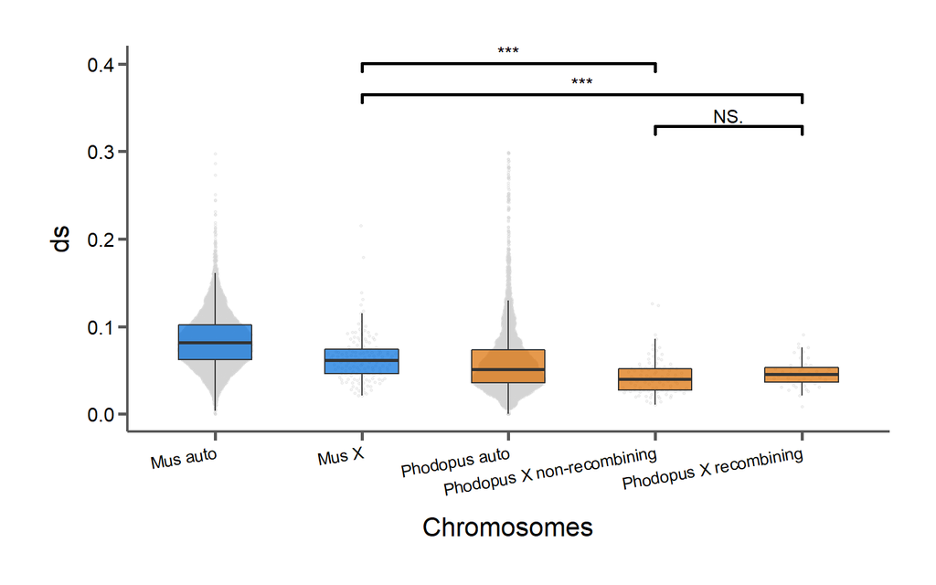

```r
phodopus_xr = subset(clade_data_f[["pho"]], pho.chr=="chrXr")
phodopus_xr$chrome = "Phodopus X recombining"
phodopus_xn = subset(clade_data_f[["pho"]], pho.chr=="chrXn")
phodopus_xn$chrome = "Phodopus X non-recombining"
phodopus_a = subset(clade_data_f[["pho"]], pho.chr!="chrXr" & pho.chr!="chrXn")
phodopus_a$chrome = "Phodopus auto"

mus_x = subset(clade_data_f[["mus"]], mm10.chr=="chrX")
mus_x$chrome = "Mus X"
mus_a = subset(clade_data_f[["mus"]], mm10.chr!="chrX")
mus_a$chrome = "Mus auto"

chrome_data = rbind(mus_a, mus_x, phodopus_a, phodopus_xr, phodopus_xn)

chrome_cols = c("#006ddb", "#006ddb", "#db6d00", "#db6d00", "#db6d00")
chrome_labs = c("Mus auto", "Mus X", "Phodopus auto", "Phodopus X recombining", "Phodopus X non-recombining")

x_comps = list(c("Phodopus X recombining", "Phodopus X non-recombining"), c("Mus X", "Phodopus X recombining"), c("Mus X", "Phodopus X non-recombining"))

chrome_ds_p = ggplot(chrome_data, aes(chrome, clade.ds, fill=chrome)) +
  geom_quasirandom(size=0.5, alpha=0.3, width=0.25, color="#d3d3d3") +
  geom_boxplot(outlier.shape=NA, alpha=0.7, width=0.5) +
  geom_signif(comparisons=x_comps, map_signif_level=TRUE, textsize=4, size=1, step_increase=0.12, margin_top=0.1) +
  xlab("Chromosomes") +
  ylab("ds") +
  scale_fill_manual(limits=chrome_labs, values=chrome_cols) +
  bartheme() +
  theme(legend.position="none",
        axis.text.x = element_text(angle=10, hjust=1, size=10)
        )

print(chrome_ds_p)
```

## 5. X vs. autosome dN distributions in Mus and Phodopus, partitioning Phodopus X between recombining and non-recombining regions

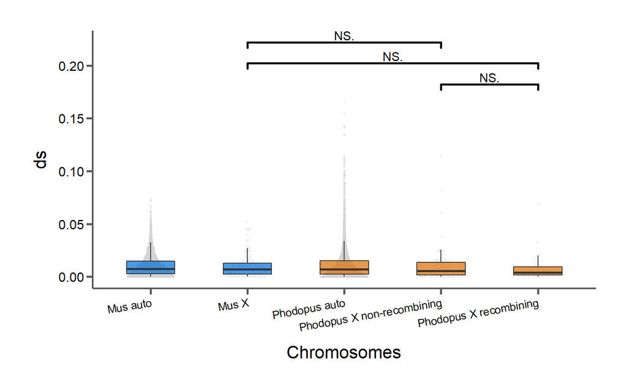

```r
chrome_cols = c("#006ddb", "#006ddb", "#db6d00", "#db6d00", "#db6d00")
chrome_labs = c("Mus auto", "Mus X", "Phodopus auto", "Phodopus X recombining", "Phodopus X non-recombining")

x_comps = list(c("Phodopus X recombining", "Phodopus X non-recombining"), c("Mus X", "Phodopus X recombining"), c("Mus X", "Phodopus X non-recombining"))

chrome_dn_p = ggplot(chrome_data, aes(chrome, clade.dn, fill=chrome)) +
  geom_quasirandom(size=0.5, alpha=0.3, width=0.25, color="#d3d3d3") +
  geom_boxplot(outlier.shape=NA, alpha=0.7, width=0.5) +
  geom_signif(comparisons=x_comps, map_signif_level=TRUE, textsize=4, size=1, step_increase=0.12, margin_top=0.1) +
  xlab("Chromosomes") +
  ylab("ds") +
  scale_fill_manual(limits=chrome_labs, values=chrome_cols) +
  bartheme() +
  theme(legend.position="none",
        axis.text.x = element_text(angle=10, hjust=1, size=10)
        )

print(chrome_dn_p)
```

## 6. X vs. autosome dN/dS distributions in Mus and Phodopus, partitioning Phodopus X between recombining and non-recombining regions

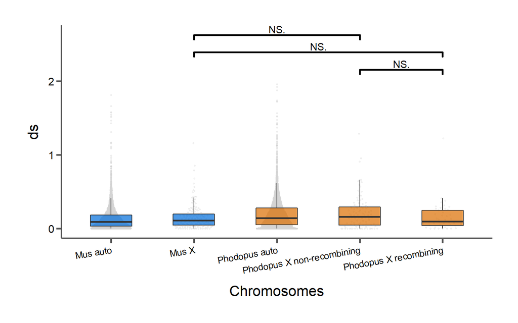

```r
chrome_cols = c("#006ddb", "#006ddb", "#db6d00", "#db6d00", "#db6d00")
chrome_labs = c("Mus auto", "Mus X", "Phodopus auto", "Phodopus X recombining", "Phodopus X non-recombining")

x_comps = list(c("Phodopus X recombining", "Phodopus X non-recombining"), c("Mus X", "Phodopus X recombining"), c("Mus X", "Phodopus X non-recombining"))

chrome_dnds_p = ggplot(chrome_data, aes(chrome, clade.dn.ds, fill=chrome)) +
  geom_quasirandom(size=0.5, alpha=0.3, width=0.25, color="#d3d3d3") +
  geom_boxplot(outlier.shape=NA, alpha=0.7, width=0.5) +
  geom_signif(comparisons=x_comps, map_signif_level=TRUE, textsize=4, size=1, step_increase=0.12, margin_top=0.1) +
  xlab("Chromosomes") +
  ylab("ds") +
  scale_fill_manual(limits=chrome_labs, values=chrome_cols) +
  bartheme() +
  theme(legend.position="none",
        axis.text.x = element_text(angle=10, hjust=1, size=10)
        )

print(chrome_dnds_p)
```

```r
t4_data = data.frame("chrome"=c("Mus auto", "Mus X", "Phodopus auto", "Phodopus X non-recombining", "Phodopus X recombining"),
                     "genes"=c(length(mus_a[,1]), length(mus_x[,1]), length(phodopus_a[,1]), length(phodopus_xn[,1]), length(phodopus_xr[,1])),
                     "avg.ds"=c(mean(mus_a$clade.ds), mean(mus_x$clade.ds), mean(phodopus_a$clade.ds), mean(phodopus_xn$clade.ds), mean(phodopus_xr$clade.ds)),
                     "avg.dn"=c(mean(mus_a$clade.dn), mean(mus_x$clade.dn), mean(phodopus_a$clade.dn), mean(phodopus_xn$clade.dn), mean(phodopus_xr$clade.dn)),
                     "avg.dnds"=c(mean(mus_a$clade.dn.ds), mean(mus_x$clade.dn.ds), mean(phodopus_a$clade.dn.ds), mean(phodopus_xn$clade.dn.ds), mean(phodopus_xr$clade.dn.ds))
                     )

rownames(t4_data) = c()

t4_data %>% kable(col.names=c("Chromosome","Number of genes", "Avg. dS", "Avg. dN", "Avg. dN/dS"), caption="Substitution rates for Mus and Phodopus branches", align="l") %>% kable_styling(bootstrap_options=c("striped", "condensed", "responsive"), full_width=F)# %>%
```

Substitution rates for Mus and Phodopus branches

| Chromosome | Number of genes | Avg. dS | Avg. dN | Avg. dN/dS |
| --- | --- | --- | --- | --- |
| Mus auto | 5352 | 0.0839927 | 0.0103321 | 0.1365710 |
| Mus X | 144 | 0.0637417 | 0.0096819 | 0.1626312 |
| Phodopus auto | 4473 | 0.0612183 | 0.0122234 | 0.1984053 |
| Phodopus X non-recombining | 96 | 0.0425031 | 0.0100156 | 0.2141042 |
| Phodopus X recombining | 45 | 0.0467400 | 0.0077800 | 0.1589244 |

```r
  #column_spec(1, width="7em") %>%
  #column_spec(2, width="13em")
```

# Results summary

1. High concordance among gene trees and species tree, and between species tree methods.
2. Branch leading to Phodopus has significantly lower dS and higher dN/dS than branch leading to Mus (no difference in dN).
3. Lower dS observed on X chromosome on both Mus and Phodopus branches.
4. No significant faster-X (higher dN/dS) observed on either branch (??) – though we do observe this in a pairwise comparison of musculus and spretus (not shown).
5. No difference in rates in the recombining and non-recombining regions of the X chromosome in Phodopus.

# Possible issues

1. Low number of genes on X chromosome in analysis (<200 for both Mus and Phodopus branches).

```r
cat("Page last updated:", format(Sys.time(), "%m/%d/%Y %H:%M:%S %Z"))
```

```
## Page last updated: 10/29/2020 22:18:07 MDT
```

```r
htmltools::includeHTML("../html-chunks/rmd_footer.html")
```

Site designed and maintained by [Gregg Thomas](https://gwct.github.io)